# Recruitment

Dustin Pashouwer

# Recruitment

*Programmed in R*

## Analyses

#### Calculate the Share of Teachers Who Are New Hires —————————————-

**Purpose:** Describe the share of teachers in the agency who are new hires.

**Required Analysis File Variables:**

- `tid`
- `school_year`
- `t_newhire`
- `t_novice`

**Analysis-specific sample restrictions**

- Keep only years for which new hire information is available.

**Ask Yourself**

- How is your workforce balanced between novice and veteran teachers? Is the ratio what you expected?
- What are the major sources of novice new hires in your agency? Experienced new hires?
- How does your recruiting strategy affect the composition of your teacher workforce?

**Potential further analyses**

```r
# // Step 1: Load the Teacher_Year_Analysis data file.
teacher_year_analysis <- read_dta(here("data/Teacher_Year_Analysis.dta"))

# // Step 2: Restrict the analysis sample.
teacher_year_analysis %<>%
  filter(
    school_year > 2010,
    !is.na(t_newhire),
    !is.na(t_novice),
    !is.na(t_experience)
  )

# // Step 3: Review variables.
teacher_year_analysis %>% tabyl(t_newhire)
```

```
 t_newhire    n   percent
         0 1480 0.8012994
         1  367 0.1987006
```

```r
teacher_year_analysis %>% tabyl(t_novice)
```

```
 t_novice    n    percent
        0 1771 0.95885219
        1   76 0.04114781
```

```r
teacher_year_analysis %>% tabyl(t_newhire, t_novice)
```

```
 t_newhire    0  1
         0 1480  0
         1  291 76
```

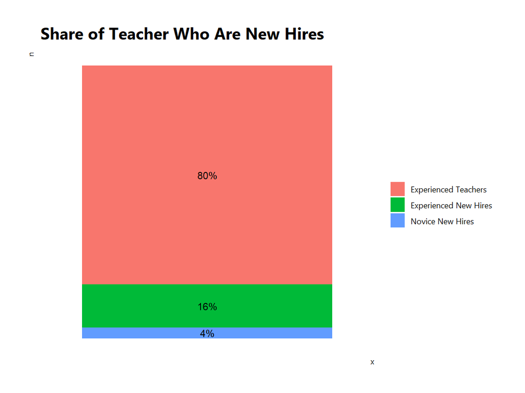

```r
# // Step 4: Define a new variable which includes both novice and experienced new hires.
teacher_year_analysis %<>%
  mutate(
    pie_hire = case_when(
      t_newhire == 0 ~ "Experienced Teachers",
      t_newhire == 1 & t_novice == 0 ~ "Experienced New Hires",
      t_newhire == 1 & t_novice == 1 ~ "Novice New Hires"
    ),
    pie_hire = factor(pie_hire, levels = c("Experienced Teachers", "Experienced New Hires", "Novice New Hires"))
  )

# // Step 5: Calculate and store sample sizes for the chart footnote.

teacher_year_analysis %>%
  tabyl(pie_hire) %>%
  ggplot(aes(x = " ", y = n, fill = pie_hire)) +
  geom_bar(stat = "identity") +
  geom_text(aes(label = scales::percent(percent, accuracy = 1)), position = position_stack(vjust = 0.5)) +
  labs(
    title = "Share of Teacher Who Are New Hires",
    fill = NULL
  ) +
  theme_tntp_2018(
    grid = FALSE,
    axis_text = FALSE
  )
```

#### Examine the Share of New Hires Across School Years —————————————-

**Purpose:** Examine trends in hiring over time.

**Required Analysis File Variables:**

- `tid`
- `school_year`
- `t_newhire`
- `t_novice`

**Analysis-specific sample restrictions**

- Keep only years for which new hire information is available.

**Ask Yourself**

- How have hiring trends changed over time?
- What factors might account for the trends that I see?

**Potential further analyses**

At the state level, yout may wish to exammine hiring trends by year for specific school types or geographic areas. At the district level, you can make a graph of this type in order to examine overall hiring by school or for specific groups of schools, instead of by year.

[figure not shown]

```r
# // Step 1: Load the Teacher_Year_Analysis data file.
teacher_year_analysis <- read_dta(here("data/Teacher_Year_Analysis.dta"))

# // Step 2: Restrict the analysis sample.
teacher_year_analysis %<>%
  filter(
    school_year > 2007,
    !is.na(t_newhire),
    !is.na(t_novice),
    !is.na(t_experience)
  )

# // Step 3:  Generate veteran new hire indicator.
teacher_year_analysis %<>%
  mutate(
    t_newhire_type = case_when(
      t_newhire == 1 & t_novice == 1 ~ "Novice New Hire",
      t_newhire == 1 & t_novice == 0 ~ "Experienced New Hire",
      TRUE ~ "Returned Teachers"
    ),
    t_newhire_type = t_newhire_type %>%
      factor(levels = c("Novice New Hire", "Experienced New Hire", "Returned Teachers"))
  )

# // Step 4:  Review variables to be used in the analysis.



# // Step 5:  Calculate counts and percentages table.
tabyl_school_year_t_newhire_type <- teacher_year_analysis %>%
  count(school_year, t_newhire_type) %>%
  group_by(school_year) %>%
  mutate(percent = n / sum(n)) %>%
  ungroup()

# // Step 6:  Calculate significance indicator variables by year.
tabyl_school_year_t_newhire_type_chisq <- tabyl_school_year_t_newhire_type %>%
  select(-percent) %>%
  spread(t_newhire_type, n) %>%
  as_tabyl() %>%
  chisq.test()

tabyl_school_year_t_newhire_type_sig <- tabyl_school_year_t_newhire_type_chisq$residuals %>%
  mutate_at(vars(-school_year), ~ ifelse(abs(.) >= 1.96, "*", "")) %>%
  gather(t_newhire_type, sig, -school_year) %>%
  mutate(school_year = as.double(school_year),
         t_newhire_type = as.factor(t_newhire_type))

# // Step 7:  Concatenate values and significance asterisks to make value labels.
school_year_by_t_newhire_type <- left_join(tabyl_school_year_t_newhire_type, tabyl_school_year_t_newhire_type_sig) %>%
  mutate(label = paste0(scales::percent(percent, accuracy = 1), sig))

# // Step 8:  Create a stacked bar graph using overlaid bars.
school_year_by_t_newhire_type %>%
  ggplot(aes(x = school_year, y = percent, fill = t_newhire_type)) +
    geom_bar(stat = "identity") +
    geom_text(aes(label = label), position = position_fill(0.5)) +
    theme_tntp_2018() +
    scale_fill_tntp()
```

```r
# Q: I use the chi-square test here, which I think is a measurement away from the mean.
# They use a regression with comparison to 2008 as a base year in the OpenSDP example. Can you do this with chi-squared?
```

**Purpose:** Examine the extent to which new hires are distributed unevenly across the agency according to school characteristics.

**Required Analysis File Variables:**

- `tid`
- `school_year`
- `t_newhire`
- `t_novice`
- `school_poverty_quartile`

**Analysis-specific sample restrictions**

- Keep only years for which new hire information is available.

**Ask Yourself**

- How do hiring patterns differ between high and low-poverty schools?
- Are the shares of novice and veteran hires distributed equitably and strategically across school poverty quartiles?

**Potential further analyses**

#### Examine the Distribution of Teachers and Students by Race —————————————-

**Purpose:** Compares the shares of all teachers, newly hired teachers, and students by race.

**Required Analysis File Variables:**

- `tid`
- `school_year`
- `t_newhire`
- `t_race_ethnicity`
- `sid`
- `s_race_ethnicity`

**Analysis-specific sample restrictions**

- For the student and teacher samples, keep only records for which race information is not missing.
- For the student and teacher samples, keep only years for which teacher new hire information is available.

**Ask Yourself**

- Is the racial composition of your teacher workforce similar to the racial composition of your student body? Is there a difference in racial composition between all teachers and newly hired teachers?
- If there is a difference between teachers and students, what impact might this have on student learning?

**Potential further analyses**

You may wish to replicate this analysis for specific schools or groups of schools.

[figure not shown]

```r
# // Step 1: Load the Teacher_Year_Analysis data file.
teacher_year_analysis <- read_dta(here("data/Teacher_Year_Analysis.dta"))

# // Step 3: Restrict the teacher sample.
teacher_year_analysis %<>%
  filter(
    school_year == 2011,
    !is.na(t_race_ethnicity)
  )

# // Step 4: Review teacher variables.


# // Step 5: Get teacher sample sizes.
tabyl_t_race_ethnicity <- teacher_year_analysis %>%
  tabyl(t_race_ethnicity) %>%
  select(
    race_ethnicity = t_race_ethnicity,
    t_total = percent
  )

tabyl_new_t_race_ethnicity <- teacher_year_analysis %>%
  filter(t_newhire == 1) %>%
  tabyl(t_race_ethnicity) %>%
  select(
    race_ethnicity = t_race_ethnicity,
    t_newhire = percent
  )

# // Step 6: Load the Student_School_Year data file to get student data.
student_teacher_year_analysis <- read_dta(here("data/Student_Teacher_Year_Analysis.dta"))

# // Step 7: Make the file unique by sid and school_year.
student_teacher_year_analysis %<>%
  distinct(sid, school_year, .keep_all = TRUE)

# // Step 8: Restrict the student sample.
student_teacher_year_analysis %<>%
  filter(
    school_year == 2011,
    !is.na(s_race_ethnicity)
  )

# // Step 9: Get student sample sizes.
tabyl_s_race_ethnicity <- student_teacher_year_analysis %>%
  tabyl(s_race_ethnicity) %>%
  select(
    race_ethnicity = s_race_ethnicity,
    s_total = percent
  )

# // Step 10: Join teacher and student data tables.
race_ethnicity_tabyl <- full_join(tabyl_t_race_ethnicity, tabyl_new_t_race_ethnicity, by = "race_ethnicity") %>%
  full_join(tabyl_s_race_ethnicity, by = "race_ethnicity")

# // Step 2: Factorize the race/ethnicity categories.
race_ethnicity_tabyl <- race_ethnicity_tabyl %>%
  filter(race_ethnicity %in% c(1, 2, 3, 5)) %>%
  mutate(race_ethnicity = case_when(
    race_ethnicity == 1 ~ "Black",
    race_ethnicity == 2 ~ "Asian",
    race_ethnicity == 3 ~ "Latino",
    race_ethnicity == 5 ~ "White"
  ))

# // Step 2: Graph the results.
race_ethnicity_tabyl %>%
  gather(type, percent, -race_ethnicity) %>%
  ggplot(aes(race_ethnicity, percent, fill = type)) +
  geom_bar(stat = "identity", position = position_dodge()) +
  geom_text(aes(label = scales::percent(percent, accuracy = 1)), position = position_dodge())
```